# Introducing {learner}, My First Package!

The {learner} package lets you use the R console as an interactive learning environment in order to memorize any dataset you want. Its main goal is to put foreign language vocabulary learning in the R workflow, so R can also be used to study languages or anything related to flashcards.

The gif below shows how to use {learner} in the R console.

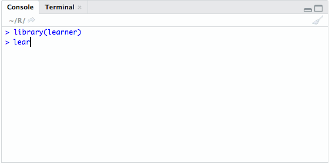

### ** Update, March 24th, 2018 **

The {learner} package is now called {polyglot}. See [this](http://felixluginbuhl.com/polyglot/) blog post for more information.

## My inspirations

I am a big fan of [**Anki**](https://apps.ankiweb.net/), a [spaced repetition](https://en.wikipedia.org/wiki/Spaced_repetition) program which priorities the [flashcards](https://en.wikipedia.org/wiki/Flashcard) you need to study. It’s a very effective application to memorize foreign vocabulary or anything you want to. And it’s free and open source.

As Anki is written in Python, I wondered if a similar program exists in the R community. The closer I could find was the impressive {[swirl](http://swirlstats.com/)} package, which teaches you R programming and data science interactively in the R console. Sadly, {swirl} is not built to study flashcards. So to fill this gap, I decided to develop the {learner} package (my first package!).

## How {learner} works

The {learner} package is built in only 3 functions. I will present them now one by one.

Let’s begin by looking at the first and longer function, called `learn`, which launches the interactive learning environment.

```r
learn <- function() {
  message("| Welcome to learner!")
  message("| Please choose a dataset to study, or type 0 to exit.")
  if(!exists("learnerStartTime")) {
    learnerStartTime <- Sys.time()
    assign("learnerStartTime", learnerStartTime, envir = .GlobalEnv)
  }
  learnerDatasetPath <- system.file("extdata/", package = "learner")
  learnerDatasetName <- select.list(list.files(path = paste0("", learnerDatasetPath, "")))
  learnerDatasetAbsolutePath <- paste0("",learnerDatasetPath,"", learnerDatasetName,"")
  assign("learnerDatasetAbsolutePath", learnerDatasetAbsolutePath, envir = .GlobalEnv)
  if (learnerDatasetName == "") {
    learnerExit() # 0 selected, exit the learning session
  } else {
    learnerDataset <- read.csv(paste0("",learnerDatasetAbsolutePath,""), stringsAsFactors = FALSE)
    assign("learnerDataset", learnerDataset, envir = .GlobalEnv)
    # Check if the dataset has at least two colomns
    if (ncol(learnerDataset) < 2) {
      message("| WARNING: Your dataset doesn't have two colomns.")
      message("| Learner needs two-colomns datasets to work correctly.\n")
      return(learn())
    } else {
      learnerDataset[,1] <- as.character(learnerDataset[,1])
      learnerDataset[,2] <- as.character(learnerDataset[,2])
      assign("learnerDataset", learnerDataset, envir = .GlobalEnv)
    }
    # Add numerical Score variable if not exists
    if (any(names(learnerDataset) == "Score")) {
      message(paste("|", learnerDatasetName,"selected, with", nrow(learnerDataset),"rows."))
      message("| Continuing learning session...\n")
    } else {
      learnerDataset$Score <- rep(as.numeric(0), nrow(learnerDataset))
      assign("learnerDataset", learnerDataset, envir = .GlobalEnv)
      write.csv(learnerDataset, file = paste0("", learnerDatasetAbsolutePath, ""), row.names = FALSE)
      message(paste("|", learnerDatasetName,"selected, with", nrow(learnerDataset),"rows."))
      message("| New learning session launched...\n")
    }
    # If NAs exist in the Score variable, replace by 0
    learnerDataset$Score[is.na(learnerDataset$Score)] <- 0
    assign("learnerDataset", learnerDataset, envir = .GlobalEnv)
    write.csv(learnerDataset, file = paste0("", learnerDatasetAbsolutePath, ""), row.names = FALSE)
    return(learnerQuestion())
  }
  invisible()
}
```

This function initializes the interactive environment by proposing to select a CSV file from the inst/extdata/ directory. The function reads the selected dataset and adds a numeric variable, named Score, if not already existing. It also replaces any existing missing values by 0 from the Score variable. It means that you can add new rows in the CSV file at any time you want. Finally the function returns to the `learnerQuestion` function, or to the `learnerExit` function if 0 is typed.

When the dataset is chosen, you will have a data.frame named `learnerDataset` in your Global Environment. If it was for instance the “French_30_Basic_expressions.csv” dataset that has been selected, the data will look like a [three-sided flashcards](https://en.wikipedia.org/wiki/Flashcard#Three-sided_cards) with a question, an answer and an hint/example (here pronunciation):

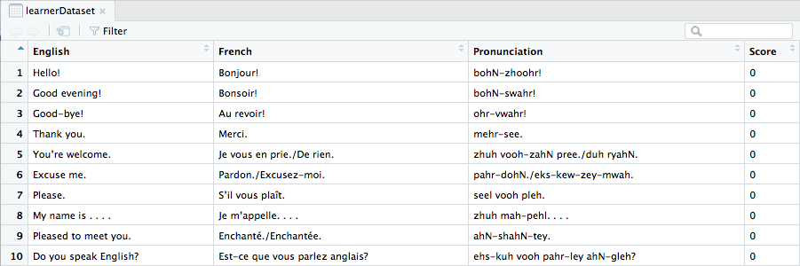

Now, let’s look at the second function, named `learnerQuestion`.

```r
learnerQuestion <- function() {
  learnerDataset <- read.csv(paste0("",learnerDatasetAbsolutePath,""), stringsAsFactors = FALSE)
  message(paste("| Question:", learnerDataset[1,1],""))
  switch(menu(c("Show answer", "Hard", "Good", "Easy", "Hint/Example", "Back to menu")) + 1,
         return(learnerExit()),
         message(paste0("| Answer: ", learnerDataset[1,2], "\n")),
         learnerDataset$Score[1] <- learnerDataset$Score[1] + 1,
         learnerDataset$Score[1] <- learnerDataset$Score[1] + 2,
         learnerDataset$Score[1] <- learnerDataset$Score[1] + 4,
         if (names(learnerDataset[3]) != "Score") {
           message(paste("| Hint/Example:", learnerDataset[1,3],"\n"))
         } else {
           message(paste("| No Hint/Example in this dataset.\n"))
         },
         return(learn()))
  learnerDataset <- learnerDataset[order(learnerDataset$Score), ]
  assign("learnerDataset", learnerDataset, envir = .GlobalEnv)
  write.csv(learnerDataset, file = paste0("", learnerDatasetAbsolutePath, ""), row.names = FALSE)
  invisible()
  return(learnerQuestion()) # create loop
}
```

Yes, I agree, the score algorithm is very basic. I will probably improve it in the next versions of the package. If you want to contribute or suggest any improvements, don’t hesitate to make a [Pull request](https://github.com/lgnbhl/learner/pulls) or to contact me.

Finally, let’s look at the `learnerExit` function.

```r
learnerExit <- function() {
  learnerEndTime <- Sys.time()
  learnerTimer <- as.numeric(learnerEndTime - learnerStartTime, units = "mins")
  if(round(learnerTimer) <= 1) {
    message(paste("| Learning session time:", round(learnerTimer),"minute."))
    } else {
    message(paste("| Learning session time:", round(learnerTimer),"minutes."))
  }
  message("| Learning score saved. Cleaning Global Environment...")
  if(exists("learnerDataset")) {
    rm(learnerDataset, envir = globalenv())
  }
  if(exists("learnerDatasetAbsolutePath")) {
    rm(learnerDatasetAbsolutePath, envir = globalenv())
  }
  if(exists("learnerStartTime")) {
    rm(learnerStartTime, envir = globalenv())
  }
  message("| Leaving learner now. Type learn() to resume.")
  invisible()
}
```

This function calculates the learning session time and print it. Then, it cleans the Global Environment if needed and displays a farewell message.

Happy learning!

#### Thanks for reading!

- For updates of recent blog posts, follow me on [Twitter](https://twitter.com/FelixLuginbuhl).
- For reproducing my data analysis, go on my [Github repo](https://github.com/lgnbhl/blogposts) or my [RStudio server](https://mybinder.org/v2/gh/lgnbhl/blogposts/master?urlpath=rstudio).
- Curious about what I can do for your organisation? Have a look my [services](https://felixluginbuhl.com).